# SBBI_2026_introduction_pipeline

2026-10-23

#Connectome practical: Exploring neuronal connectivity of the male (male CNS) and the female (FAFB/FlyWire) Drosophila datasets

The pipeline will use 2 curated datasets (differents to the ones used in Conda.science!!!!!). Download it from Dropbox folder “Datasets fot tutorial 3 (R pipeline)” (download them here: https://www.dropbox.com/scl/fo/qoui26oplmpmoqyt2mvuv/AM0kPfZXAeSkbFlS_A-mHso?rlkey=5u15cn0ltztsvy0o9skuzo7rf&st=hja1bn8z&dl=0):

We’ll start with PPL101 as the example neuron, set the minimum input and output connection weight to 5, and identify the 25 strongest connectivity partners (you can change these parameters in order to study your neurons)

The workflow will produce: 1. Imported datasets named male_cns and female_fafb. 2. Identification of the neuron(s) of interest in both datasets. 3. Separate rankings of upstream (input) and/or downstream (output) partners. 4. Plot best partners (more connected) for female in magenta and male in green. 5. Pie charts showing the relative contribution of the top 25 partners. 6. Neuroglancer links for visual inspection of the selected neurons.

An important scientific consideration: Male CNS and FAFB are not directly equivalent connectomes. The male dataset covers the whole CNS (brain + CNS), whereas FAFB covers the adult female brain. In addition, their reconstruction and annotation pipelines differ. If you want to compare between the 2 datasets only normalise the connectivity. For more details about the technical differences check out the papers: Zheng et al., 2018 (doi: 10.1016/j.cell.2018.06.019); Schlegel et al 2024 (doi: 10.1038/s41586-024-07686-5), and Berg et al., 2026 (doi: 10.1016/j.cell.2026.08.015)

Another important distinction is that PPL101 is a neuron label “type”, you could also identified them by their ID, class, superclass. Have in consideration that sometimes type labels varies a bit between datasets. Please check on http://codex.flywire.ai (FAFB/FlyWire) and/or http://https://neuprint.janelia.org/ (male CNS) for the exact name of your neurons. Or explore the Data tables.

#1. Install and load packages Do this step once and then eliminate it from the code*

```r
# Run once to install packages
install.packages(c(
  "dplyr", "tidyr", "ggplot2", "readr",
  "arrow", "stringr", "scales", "patchwork"
))

install.packages("Polychrome")


#For this packages you must to follow the instructions here (Jefferis Lab):
#https://natverse.org/install/
#https://github.com/natverse/coconatfly

install.packages("natmanager")
natmanager::install(pkgs = "coconatfly")
```

#2) Load the libraries

```r
library(natverse)
library(dplyr)
```

```r
library(tidyr)
library(ggplot2)
library(readr)
library(arrow)
library(stringr)
library(scales)
library(patchwork)
library(coconatfly)
```

#3) Import datasets Please copy pase here the location in your computer of your datasets!! (now is directed to my computer folders)

```r
female_fafb <- read_csv( "/Users/valesilvamo/Dropbox/SBBI 2026/SBBI_2026_connectome_practical/Datasets fot tutorial 3 (R pipeline)/female-fafb-consolidated_cell_types.csv", col_types = cols(.default = col_character())) %>% filter(!is.na(primary_type))

male_cns <- read_feather("/Users/valesilvamo/Dropbox/SBBI 2026/SBBI_2026_connectome_practical/Datasets fot tutorial 3 (R pipeline)/male-cns-v1.0-minconf-0.5.feather") %>% filter(!is.na(type))
```

## Inspect the datasets

```r
dim(female_fafb)
```

```
## [1] 138327      3
```

```r
dim(male_cns)
```

```
## [1] 164506     36
```

```r
#female_fafb should have 138,327 entries and 3 total columns
#male_cns 164,506 entries and 36 total columns
#if you don't see these numbers your are working with the wrong datasets, come back to Dropbox and download tutorial 3!
```

```r
#feel free to explore in details the tables (more information for the female datasets/column meaning here: female https://codex.flywire.ai/api/download?dataset=fafb&data_version=783; male https://male-cns.janelia.org/download/#__tabbed_3_2)
names(female_fafb)
```

```
## [1] "root_id"            "primary_type"       "additional_type(s)"
```

```r
names(male_cns)
```

```
##  [1] "assignedOlHex1" "assignedOlHex2" "bodyId"         "flywireType"
##  [5] "group"          "instance"       "somaSide"       "statusLabel"
##  [9] "superclass"     "type"           "vfbId"          "hemibrainType"
## [13] "itoleeHl"       "supertype"      "birthtime"      "mancBodyid"
## [17] "mancGroup"      "mancType"       "subclass"       "synonyms"
## [21] "class"          "rootSide"       "somaNeuromere"  "trumanHl"
## [25] "dimorphism"     "matchingNotes"  "entryNerve"     "mancSerial"
## [29] "mcnsSerial"     "serialMotif"    "fruDsx"         "exitNerve"
## [33] "receptorType"   "somaLocation"   "tosomaLocation" "status"
```

```r
glimpse(female_fafb)
```

```
## Rows: 138,327
## Columns: 3
## $ root_id              <chr> "720575940599457990", "720575940599763910", "7205…
## $ primary_type         <chr> "T4b", "T5b", "Dm3q", "KCg-m", "JO-CA", "hDeltaJ"…
## $ `additional_type(s)` <chr> NA, NA, NA, NA, NA, NA, NA, "KCab-s", NA, "PS225"…
```

```r
glimpse(male_cns)
```

```
## Rows: 164,506
## Columns: 36
## $ assignedOlHex1 <dbl> NA, NA, NA, NA, NA, NA, NA, NA, NA, NA, NA, NA, NA, NA,…
## $ assignedOlHex2 <dbl> NA, NA, NA, NA, NA, NA, NA, NA, NA, NA, NA, NA, NA, NA,…
## $ bodyId         <int> 10001, 10002, 10003, 10005, 10006, 10009, 10010, 10011,…
## $ flywireType    <chr> "DNp01", "OCG01d", "VCH", "AOTU019", "VS1,VS2,VS3,VS4,V…
## $ group          <dbl> 10001, 10002, 10003, 10005, 10006, 10009, 10001, 10011,…
## $ instance       <chr> "DNp01(GF)_R", "OCG01d_L", "VCH_R", "AOTU019_R", "VS_L"…
## $ somaSide       <chr> "R", "L", "R", "R", "L", "L", "L", "L", "R", "R", "R", …
## $ statusLabel    <ord> Roughly traced, Roughly traced, Prelim Roughly traced, …
## $ superclass     <chr> "descending_neuron", "visual_projection", "visual_centr…
## $ type           <chr> "DNp01", "OCG01d", "VCH", "AOTU019", "VS", "CT1", "DNp0…
## $ vfbId          <chr> "VFB_jrmc30my", "VFB_jrmc1nh6", "VFB_jrmc074n", "VFB_jr…
## $ hemibrainType  <chr> "Giant Fiber", "OCG01", "VCH", "AOTU019", "VS", "CT1", …
## $ itoleeHl       <chr> "putative_primary", NA, "putative_primary", "putative_p…
```

[output cut: 23 more lines]

#4) Explore the connectivity using coconatfly package (https://github.com/natverse/coconatfly)

```r
# 1. PARAMETERS (feel free to study other neurons and use different thresholds)

neuron_name <- "PPL101"
threshold <- 5

# 2. FIND NEURONS IN BOTH DATASETS

# Female FAFB
female_ids <- female_fafb %>%
  filter(primary_type == neuron_name) %>%
  pull(root_id) %>%
  as.character()

# Male CNS
male_ids <- male_cns %>%
  filter(type == neuron_name) %>%
  pull(bodyId) %>%
  as.character()

# Check identified neurons
print(female_ids)
```

```
## [1] "720575940617691170" "720575940621040737"
```

```r
print(male_ids)
```

```
## [1] "11327" "11900"
```

```r
# 3. RETRIEVE INPUTS (you can also do it for only outputs, or both, check the help section of the packages for more details)


# Female FAFB / FlyWire
female_partners <- cf_partners(
  cf_ids(flywire = female_ids),
  partners = c("inputs"),
  threshold = threshold
)
```

```
## Updating 6895 ids
```

```
## flywire_rootid_cached: Looking up 6895 missing keys
```

```
## Updating 6955 ids
```

```
## flywire_rootid_cached: Looking up 6955 missing keys
```

```r
# Male CNS
male_partners <- cf_partners(
  cf_ids(malecns = male_ids),
  partners = c("inputs"),
  threshold = threshold
)
```

```
## Using malecns dataset `male-cns:v0.9`.
```

```
## See ?malecns section Package Options for details.
```

```
## For high-quality h5 bridging registrations (malecns <-> JRC2018U),
## run mcns_download_xforms2() once to download, then
## mcns_register_xforms2() once per session to activate.
```

```r
# 4. INSPECT RESULTS

head(female_partners)
```

```
## # A tibble: 6 × 19
##    pre_id post_id weight top_np   supervoxel_id     side  flow  class cell_class
##   <int64> <int64>  <int> <chr>    <chr>             <chr> <chr> <chr> <chr>
## 1    7e17    7e17    112 SMP_L    78814161911716663 L     intr… cent… <NA>
## 2    7e17    7e17    109 SMP_L    78253067518458277 L     intr… cent… <NA>
## 3    7e17    7e17    106 SMP_L    81492091469403284 R     intr… cent… <NA>
## 4    7e17    7e17    103 SMP_L    80221880325358273 R     intr… cent… <NA>
## 5    7e17    7e17    102 MB_PED_L 78323023677138555 L     intr… cent… MBON
## 6    7e17    7e17    101 SMP_R    77548486790578252 L     intr… cent… <NA>
## # ℹ 10 more variables: cell_sub_class <chr>, type <chr>, top_nt <chr>,
## #   ito_lee_hemilineage <chr>, hemibrain_type <chr>, malecns_type <chr>,
## #   fbbt_id <chr>, dataset <chr>, pre_key <chr>, post_key <chr>
```

```r
head(male_partners)
```

```
##   bodyid partner prepost weight                  name   type  group
## 1  11900   17878       0    365 GNG321(hb612095452)_R GNG321  11038
## 2  11327   11038       0    295 GNG321(hb582372162)_L GNG321  11038
## 3  11900  512187       0    289              SMP056_L SMP056 512187
## 4  11900   13526       0    288              SMP026_R SMP026  13526
## 5  11327   17988       0    274              SMP053_R SMP053  17988
## 6  11900  520083       0    261              SMP053_L SMP053  17988
##          class somaSide side pre_id post_id dataset   pre_key post_key
## 1 cb_intrinsic        R    R  17878   11900 malecns  mc:17878 mc:11900
## 2 cb_intrinsic        L    L  11038   11327 malecns  mc:11038 mc:11327
## 3 cb_intrinsic        L    L 512187   11900 malecns mc:512187 mc:11900
## 4 cb_intrinsic        R    R  13526   11900 malecns  mc:13526 mc:11900
## 5 cb_intrinsic        R    R  17988   11327 malecns  mc:17988 mc:11327
## 6 cb_intrinsic        L    L 520083   11900 malecns mc:520083 mc:11900
```

```r
dim(female_partners)
```

```
## [1] 748  19
```

```r
dim(male_partners)
```

```
## [1] 2516   15
```

```r
# 5. FILTER UNTYPED NEURONS

female_partners <- female_partners %>%
  filter(
    !is.na(type),
    !type %in% c("", "Unannotated")
  )

male_partners <- male_partners %>%
  filter(
    !is.na(type),
    !type %in% c("", "Unannotated")
  )
```

#5) Normalisation and ranking the partners of your neurons of interest Important to have in consideration that both dataset were obtain with different Electron microsocopies, different techniques and also are different animals so always normalise instead of using raw data to see patterns.

Remember we are working with PPL101 but you can change that and look your circuit of interest!

```r
# ==============================================
# 1. CREATE NEURON TYPE LOOKUP TABLES
# ==============================================

female_types <- female_fafb %>%
  transmute(
    partner_id = as.character(root_id),
    partner_type = as.character(primary_type)
  ) %>%
  distinct(partner_id, .keep_all = TRUE)

male_types <- male_cns %>%
  transmute(
    partner_id = as.character(bodyId),
    partner_type = as.character(type)
  ) %>%
  distinct(partner_id, .keep_all = TRUE)


# ==============================================
# 2. EXTRACT INDIVIDUAL INPUT PARTNERS
# ==============================================

female_individual <- female_partners %>%
  mutate(
    pre_id = as.character(pre_id),
    post_id = as.character(post_id)
  ) %>%
  filter(post_id %in% female_ids) %>%
  transmute(
    sex = "Female",
    neuron_id = post_id,
    partner_id = pre_id,
    weight = as.numeric(weight)
  ) %>%
  left_join(female_types, by = "partner_id")

male_individual <- male_partners %>%
  mutate(
    pre_id = as.character(pre_id),
    post_id = as.character(post_id)
  ) %>%
  filter(post_id %in% male_ids) %>%
  transmute(
    sex = "Male",
    neuron_id = post_id,
    partner_id = pre_id,
    weight = as.numeric(weight)
  ) %>%
  left_join(male_types, by = "partner_id")


# ==============================================
# 3. COMBINE INDIVIDUAL PARTNERS
# ==============================================

all_partners <- bind_rows(
  female_individual,
  male_individual
) %>%
  filter(
    !is.na(partner_type),
    !tolower(trimws(partner_type)) %in%
      c("", "unannotated")
  ) %>%
  group_by(sex, neuron_id, partner_id, partner_type) %>%
  summarise(
    weight = sum(weight, na.rm = TRUE),
    .groups = "drop"
  )


# ==============================================
# 4. NORMALISE PER PPL101 NEURON
# ==============================================

all_partners <- all_partners %>%
  group_by(sex, neuron_id) %>%
  mutate(
    total_weight = sum(weight),
    proportion = weight / total_weight,
    percentage = proportion * 100
  ) %>%
  arrange(desc(weight), .by_group = TRUE) %>%
  mutate(rank = row_number()) %>%
  ungroup()


# ==============================================
# 5. GROUP PARTNERS BY TYPE
# ==============================================

all_partners_group_by_type <- all_partners %>%
  group_by(sex, neuron_id, partner_type) %>%
  summarise(
    weight = sum(weight),
    n_neurons = n_distinct(partner_id),
    .groups = "drop"
  ) %>%
  group_by(sex, neuron_id) %>%
  mutate(
    total_weight = sum(weight),
    proportion = weight / total_weight,
    percentage = proportion * 100
  ) %>%
  arrange(desc(weight), .by_group = TRUE) %>%
  mutate(rank = row_number()) %>%
  ungroup()


# ==============================================
# 6. CHECK NORMALISATION
# ==============================================

# Individual partners
all_partners %>%
  group_by(sex, neuron_id) %>%
  summarise(
    total_percentage = sum(percentage),
    .groups = "drop"
  )
```

```
## # A tibble: 4 × 3
##   sex    neuron_id          total_percentage
##   <chr>  <chr>                         <dbl>
## 1 Female 720575940617691170            100
## 2 Female 720575940621040737            100.
## 3 Male   11327                         100.0
## 4 Male   11900                         100.0
```

```r
# Grouped by neuronal type
all_partners_group_by_type %>%
  group_by(sex, neuron_id) %>%
  summarise(
    total_percentage = sum(percentage),
    .groups = "drop"
  )
```

```
## # A tibble: 4 × 3
##   sex    neuron_id          total_percentage
##   <chr>  <chr>                         <dbl>
## 1 Female 720575940617691170              100
## 2 Female 720575940621040737              100
## 3 Male   11327                           100
## 4 Male   11900                           100
```

```r
# ==============================================
# 7. EXPORT TABLES
# ==============================================

write.csv(
  all_partners,
  "PPL101_all_individual_partners.csv",
  row.names = FALSE
)

write.csv(
  all_partners_group_by_type,
  "PPL101_partners_grouped_by_type.csv",
  row.names = FALSE
)
```

#6) Frecuency plots

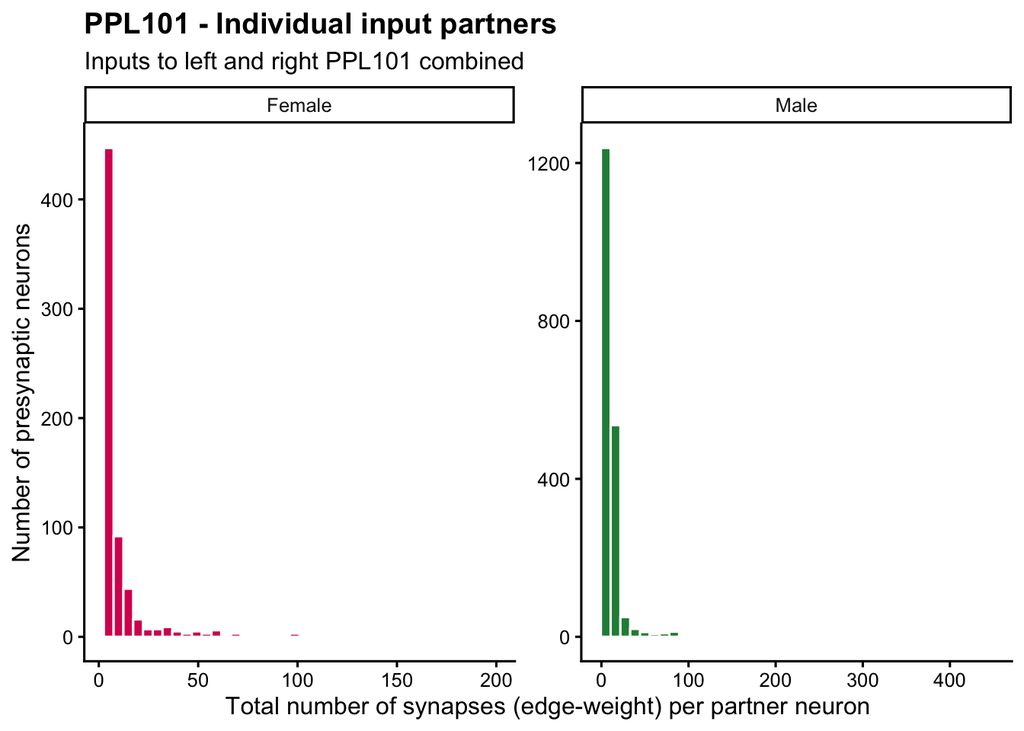

```r
# ==============================================
# FREQUENCY DISTRIBUTION PER PARTNER ID
# COMBINING LEFT AND RIGHT PPL101
# ==============================================


female_colour <- "#D81B60"
male_colour   <- "#238B45"

# 1. COMBINE INPUTS TO LEFT AND RIGHT PPL101 (both hemispheres, always important to analyse them independently and together)
# Each presynaptic partner ID appears only once
# per dataset.

all_partners_combined <- all_partners %>%
  group_by(sex, partner_id) %>%
  summarise(
    weight = sum(weight, na.rm = TRUE),
    .groups = "drop"
  )

# 2. FREQUENCY PLOT

frequency_individual <- ggplot(
  all_partners_combined,
  aes(x = weight, fill = sex)
) +
  geom_histogram(
    bins = 40,
    colour = "white"
  ) +
  facet_wrap(~sex, scales = "free") +
  scale_fill_manual(
    values = c(
      Female = female_colour,
      Male = male_colour
    )
  ) +
  labs(
    title = paste(
      neuron_name,
      "- Individual input partners"
    ),
    subtitle = "Inputs to left and right PPL101 combined",
    x = "Total number of synapses (edge-weight) per partner neuron",
    y = "Number of presynaptic neurons"
  ) +
  theme_classic(base_size = 12) +
  theme(
    legend.position = "none",
    plot.title = element_text(face = "bold")
  )

print(frequency_individual)
```

```r
# 3. SAVE FIGURE

ggsave(
  paste0(neuron_name, "_frequency_combined_LR.png"),
  frequency_individual,
  width = 10,
  height = 5,
  dpi = 300
)
```

#7) Plot of the 25 top inputs partners grouped by type (rank)

```r
# ==============================================
# 7. TOP 25 INPUT PARTNERS GROUPED BY TYPE
# ==============================================

# PARAMETERS
top_n <- 25 # <-- (you can edit this)

female_colour <- "#D81B60"
male_colour   <- "#238B45"


# ----------------------------------------------
# 1. COMBINE LEFT AND RIGHT PPL101 BY TYPE
# ----------------------------------------------

# Start from individual synaptic weights,
# not previously normalised proportions.

combined_partners_by_type <- all_partners %>%
  group_by(sex, partner_type) %>%
  summarise(
    weight = sum(weight, na.rm = TRUE),
    n_partner_neurons = n_distinct(partner_id),
    .groups = "drop"
  ) %>%
  group_by(sex) %>%
  mutate(
    total_weight = sum(weight),
    proportion = weight / total_weight,
    percentage = proportion * 100
  ) %>%
  arrange(desc(weight), .by_group = TRUE) %>%
  mutate(rank = row_number()) %>%
  ungroup()


# ----------------------------------------------
# 2. CHECK NORMALISATION
# ----------------------------------------------

combined_partners_by_type %>%
  group_by(sex) %>%
  summarise(
    n_types = n(),
    total_synapses = sum(weight),
    total_percentage = sum(percentage),
    .groups = "drop"
  )
```

```
## # A tibble: 2 × 4
##   sex    n_types total_synapses total_percentage
##   <chr>    <int>          <dbl>            <dbl>
## 1 Female     117           8164            100.0
## 2 Male       163          27709            100.
```

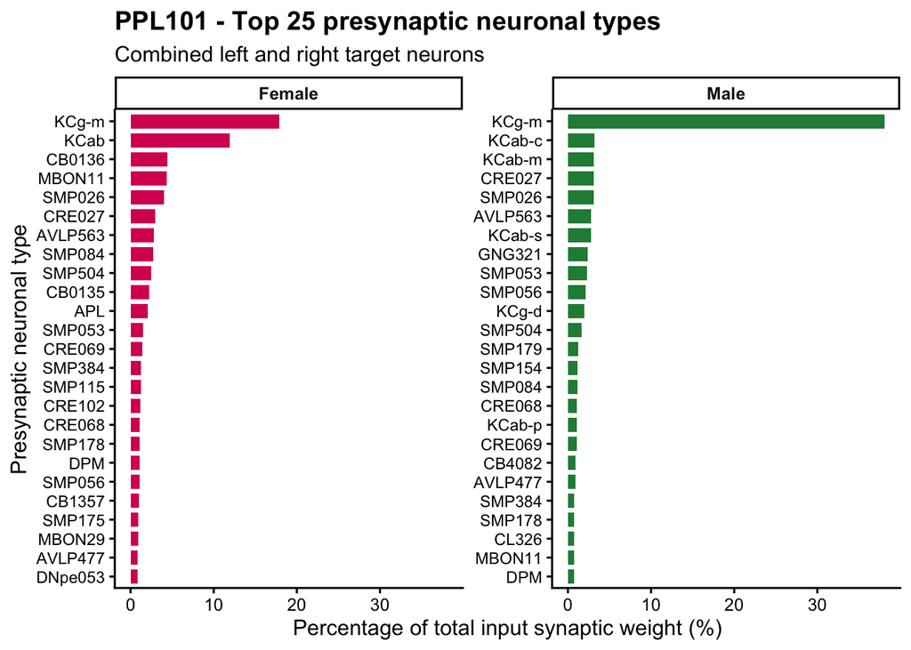

```r
# ----------------------------------------------
# 3. SELECT TOP 25 TYPES PER DATASET
# ----------------------------------------------

top25_types <- combined_partners_by_type %>%
  group_by(sex) %>%
  slice_min(
    order_by = rank,
    n = top_n,
    with_ties = FALSE
  ) %>%
  ungroup()

# Inspect results
View(top25_types)


# ----------------------------------------------
# 4. PREPARE PLOT DATA
# ----------------------------------------------

plot_data <- top25_types %>%
  mutate(
    sex = factor(sex, levels = c("Female", "Male")),
    partner_label = paste(
      partner_type, sex, sep = "___"
    )
  )


# ----------------------------------------------
# 5. BAR PLOT
# ----------------------------------------------

ranking_plot <- ggplot(
  plot_data,
  aes(
    x = reorder(partner_label, percentage),
    y = percentage,
    fill = sex
  )
) +
  geom_col(width = 0.75) +
  coord_flip() +
  facet_wrap(
    ~sex,
    scales = "free_y"
  ) +
  scale_x_discrete(
    labels = function(x) sub("___.*$", "", x)
  ) +
  scale_fill_manual(
    values = c(
      Female = female_colour,
      Male = male_colour
    )
  ) +
  labs(
    title = paste(
      neuron_name,
      "- Top 25 presynaptic neuronal types"
    ),
    subtitle = "Combined left and right target neurons",
    x = "Presynaptic neuronal type",
    y = "Percentage of total input synaptic weight (%)"
  ) +
  theme_classic(base_size = 12) +
  theme(
    strip.text = element_text(face = "bold"),
    plot.title = element_text(face = "bold"),
    axis.text.y = element_text(size = 9),
    legend.position = "none"
  )

print(ranking_plot)
```

```r
# ----------------------------------------------
# 6. SAVE RANKING AND FIGURE
# ----------------------------------------------

write.csv(
  combined_partners_by_type,
  paste0(neuron_name, "_combined_ranking_by_type.csv"),
  row.names = FALSE
)

ggsave(
  paste0(neuron_name, "_top25_types.png"),
  ranking_plot,
  width = 13,
  height = 10,
  dpi = 300
)
```

# 8) Pie chart plot for the top 25 input top partners

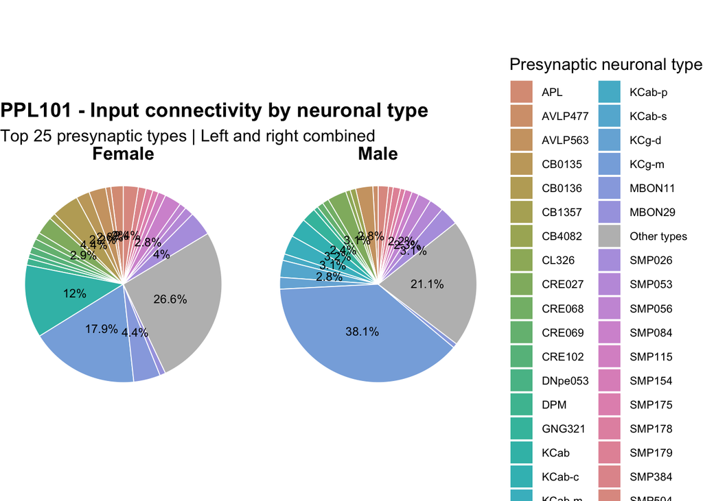

```r
# ----------------------------------------------
# 1. PREPARE DATA
# ----------------------------------------------

pie_data <- combined_partners_by_type %>%
  mutate(
    category = if_else(
      rank <= top_n,
      partner_type,
      "Other types"
    )
  ) %>%
  group_by(sex, category) %>%
  summarise(
    percentage = sum(percentage),
    .groups = "drop"
  )

# ----------------------------------------------
# 2. CREATE VIBRANT, CONSISTENT COLOURS
# ----------------------------------------------

neuron_types <- sort(unique(
  pie_data$category[pie_data$category != "Other types"]
))

type_colours <- grDevices::hcl.colors(
  n = length(neuron_types),
  palette = "Dynamic"
)

names(type_colours) <- neuron_types

type_colours <- c(
  type_colours,
  "Other types" = "#BDBDBD"
)

# ----------------------------------------------
# 3. ADD PERCENTAGE LABELS
# ----------------------------------------------

pie_data <- pie_data %>%
  mutate(
    label = if_else(
      percentage >= 2,
      paste0(round(percentage, 1), "%"),
      ""
    )
  )

# ----------------------------------------------
# 4. PIE CHART
# ----------------------------------------------

pie_plot <- ggplot(
  pie_data,
  aes(
    x = "",
    y = percentage,
    fill = category
  )
) +
  geom_col(
    width = 1,
    colour = "white",
    linewidth = 0.3
  ) +
  geom_text(
    aes(label = label),
    position = position_stack(vjust = 0.5),
    size = 3,
    colour = "black"
  ) +
  coord_polar(theta = "y") +
  facet_wrap(~sex) +
  scale_fill_manual(
    values = type_colours
  ) +
  labs(
    title = paste(
      neuron_name,
      "- Input connectivity by neuronal type"
    ),
    subtitle = "Top 25 presynaptic types | Left and right combined",
    fill = "Presynaptic neuronal type"
  ) +
  theme_void(base_size = 12) +
  theme(
    strip.text = element_text(
      face = "bold",
      size = 13
    ),
    plot.title = element_text(face = "bold"),
    legend.position = "right",
    legend.text = element_text(size = 8)
  )

print(pie_plot)
```

```r
# ----------------------------------------------
# 5. SAVE FIGURE
# ----------------------------------------------

ggsave(
  paste0(neuron_name, "_top25_types_piechart.png"),
  pie_plot,
  width = 15,
  height = 8,
  dpi = 300
)
```

# 9) Example of how to visualise our neurons of interest and/or its partners!

neuroglancer is a platform to visualise the neurons. More details here: https://allenswdb.github.io/anatomy/microns-em/em-neuroglancer.html

```r
# ----------------------------------------------
# 1. SELECT NEURONS TO VISUALISE
# ----------------------------------------------

#First! female

# PPL101 neurons (left and right)
target_ids <- as.character(female_ids)

# Top 25 individual presynaptic partners
top_partner_ids <- all_partners %>%
  filter(sex == "Female") %>%
  group_by(partner_id) %>%
  summarise(
    weight = sum(weight),
    .groups = "drop"
  ) %>%
  slice_max(
    weight,
    n = 25,
    with_ties = FALSE
  ) %>%
  pull(partner_id) %>%
  as.character()

# ----------------------------------------------
# 2. GENERATE NEUROGLANCER LINKS
# ----------------------------------------------

# PPL101 neurons only
ppl101_url <- fafbseg::flywire_scene(
  ids = target_ids,
  open = FALSE
)

# PPL101 and its top 25 input partners
network_url <- fafbseg::flywire_scene(
  ids = unique(c(target_ids, top_partner_ids)),
  open = FALSE
)

# ----------------------------------------------
# 3. OPEN IN BROWSER
# ----------------------------------------------

cat("PPL101 Neuroglancer link:\n", ppl101_url, "\n")
```

```
## PPL101 Neuroglancer link:
##  https://ngl.flywire.ai/#!%7B%22layers%22%3A%5B%7B%22source%22%3A%22precomputed%3A%2F%2Fgs%3A%2F%2Fmicrons-seunglab%2Fdrosophila_v0%2Falignment%2Fimage_rechunked%22%2C%22type%22%3A%22image%22%2C%22blend%22%3A%22default%22%2C%22shaderControls%22%3A%7B%7D%2C%22name%22%3A%22Production-image%22%7D%2C…
```

```r
cat("PPL101 + top 25 partners:\n", network_url, "\n")
```

```
## PPL101 + top 25 partners:
##  https://ngl.flywire.ai/#!%7B%22layers%22%3A%5B%7B%22source%22%3A%22precomputed%3A%2F%2Fgs%3A%2F%2Fmicrons-seunglab%2Fdrosophila_v0%2Falignment%2Fimage_rechunked%22%2C%22type%22%3A%22image%22%2C%22blend%22%3A%22default%22%2C%22shaderControls%22%3A%7B%7D%2C%22name%22%3A%22Production-image%22%7D%2C…
```

```r
# Open selected scene
browseURL(ppl101_url)
browseURL(network_url)
```

#Last bit!

```r
#For better images please check it out --> https://allenswdb.github.io/anatomy/microns-em/em-neuroglancer.html
#as well the connectome papers, all of them have their own "neuroglancer" link on material and methods with some extra layers of shape of brains, neuropils, etc. Super helpful
```